# TravelPackage_RaviPotlachervu

```
ProdTaken     0    1   All
OwnCar
All        3968  920  4888
1          2472  560  3032
0          1496  360  1856
------------------------------------------------------------------------------------------------------------------------
```

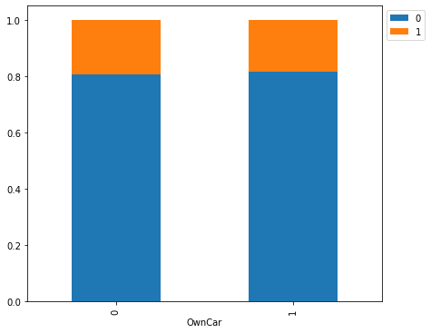

```python
stacked_barplot(data, "OwnCar", "ProdTaken")
```

```
ProdTaken     0    1   All
Passport
All        3968  920  4888
1           928  494  1422
0          3040  426  3466
------------------------------------------------------------------------------------------------------------------------
```

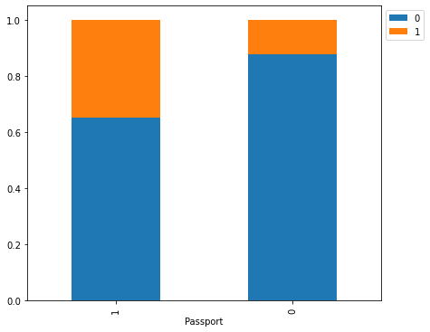

```python
stacked_barplot(data, "Passport", "ProdTaken")
```

```
ProdTaken     0    1   All
CityTier
All        3968  920  4888
1          2670  520  3190
3          1146  354  1500
2           152   46   198
------------------------------------------------------------------------------------------------------------------------
```

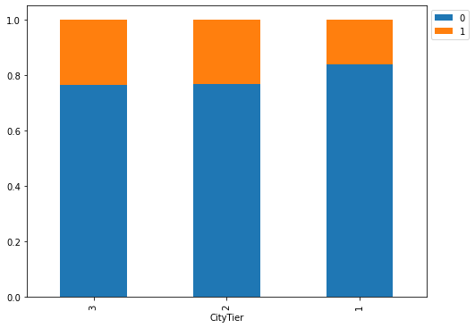

```python
stacked_barplot(data, "CityTier", "ProdTaken")
```

```python
### function to plot distributions wrt target


def distribution_plot_wrt_target(data, predictor, target):

    fig, axs = plt.subplots(2, 2, figsize=(12, 10))

    target_uniq = data[target].unique()

    axs[0, 0].set_title("Distribution of target for target=" + str(target_uniq[0]))
    sns.histplot(
        data=data[data[target] == target_uniq[0]],
        x=predictor,
        kde=True,
        ax=axs[0, 0],
        color="teal",
        stat="density",
    )

    axs[0, 1].set_title("Distribution of target for target=" + str(target_uniq[1]))
    sns.histplot(
        data=data[data[target] == target_uniq[1]],
        x=predictor,
        kde=True,
        ax=axs[0, 1],
        color="orange",
        stat="density",
    )

    axs[1, 0].set_title("Boxplot w.r.t target")
    sns.boxplot(data=data, x=target, y=predictor, ax=axs[1, 0], palette="gist_rainbow")

    axs[1, 1].set_title("Boxplot (without outliers) w.r.t target")
    sns.boxplot(
        data=data,
        x=target,
        y=predictor,
        ax=axs[1, 1],
        showfliers=False,
        palette="gist_rainbow",
    )

    plt.tight_layout()
    plt.show()
```

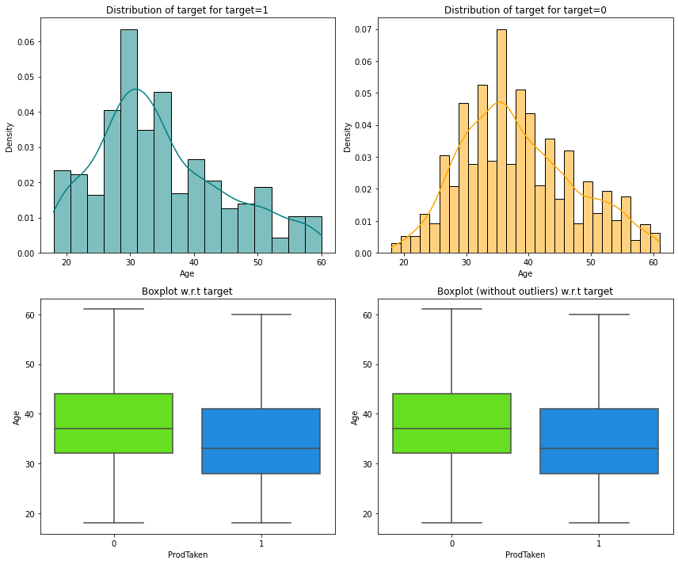

```python
distribution_plot_wrt_target(data, "Age", "ProdTaken")
```

```python
print(num_cols)
```

```
['ProdTaken', 'Age', 'CityTier', 'DurationOfPitch', 'NumberOfPersonVisiting', 'NumberOfFollowups', 'PreferredPropertyStar', 'NumberOfTrips', 'Passport', 'PitchSatisfactionScore', 'OwnCar', 'NumberOfChildrenVisiting', 'MonthlyIncome']
```

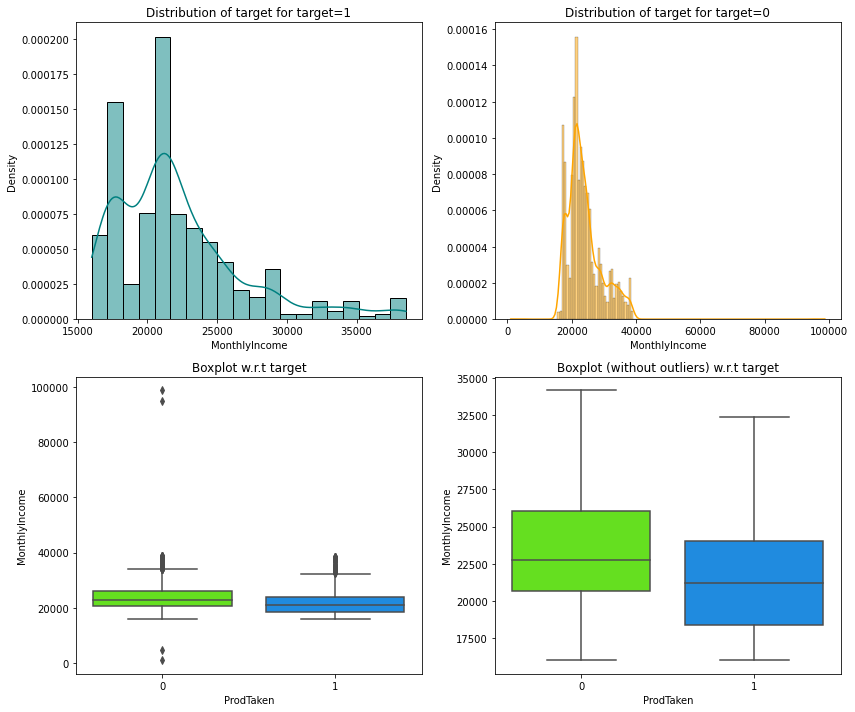

```python
distribution_plot_wrt_target(data, "MonthlyIncome", "ProdTaken")
```

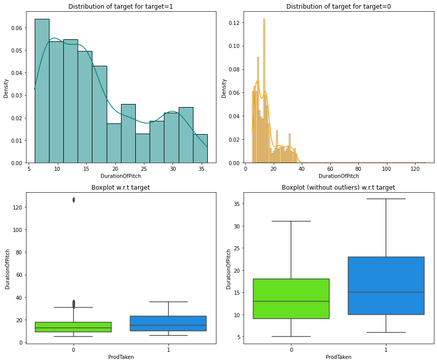

```python
distribution_plot_wrt_target(data, "DurationOfPitch", "ProdTaken")
```

### Let's find the percentage of outliers, in each column of the data, using IQR.

```python
Q1 = data.quantile(0.25)  # To find the 25th percentile and 75th percentile.
Q3 = data.quantile(0.75)

IQR = Q3 - Q1  # Inter Quantile Range (75th perentile - 25th percentile)

lower = (
    Q1 - 1.5 * IQR
)  # Finding lower and upper bounds for all values. All values outside these bounds are outliers
upper = Q3 + 1.5 * IQR
```

```python
(
    (data.select_dtypes(include=["float64", "int64"]) < lower)
    | (data.select_dtypes(include=["float64", "int64"]) > upper)
).sum() / len(data) * 100
```

```
Age                         0.000000
DurationOfPitch             2.291326
NumberOfPersonVisiting      0.061375
NumberOfFollowups           6.382979
PreferredPropertyStar       0.000000
NumberOfTrips               2.229951
PitchSatisfactionScore      0.000000
NumberOfChildrenVisiting    0.000000
MonthlyIncome               7.528642
dtype: float64
```

- We idenitified outliers and we can decide whether to treat or remove them or not. There will be outliers in real case scenario and we want to our model to learn the underling pattern for such customers.

## Customer Profiling

- Lets create customer profile for customer whose the product.

```python
df_cp=data[data['ProdTaken']==1]
```

```python
df_cp.head()
```

|  | ProdTaken | Age | TypeofContact | CityTier | DurationOfPitch | Occupation | Gender | NumberOfPersonVisiting | NumberOfFollowups | ProductPitched | PreferredPropertyStar | MaritalStatus | NumberOfTrips | Passport | PitchSatisfactionScore | OwnCar | NumberOfChildrenVisiting | Designation | MonthlyIncome |
| --- | --- | --- | --- | --- | --- | --- | --- | --- | --- | --- | --- | --- | --- | --- | --- | --- | --- | --- | --- |
| 0 | 1 | 41.0 | Self Enquiry | 3 | 6.0 | Salaried | Female | 3 | 3.0 | Deluxe | 3.0 | Single | 1.0 | 1 | 2 | 1 | 0.0 | Manager | 20993.0 |
| 2 | 1 | 37.0 | Self Enquiry | 1 | 8.0 | Free Lancer | Male | 3 | 4.0 | Basic | 3.0 | Single | 7.0 | 1 | 3 | 0 | 0.0 | Executive | 17090.0 |
| 14 | 1 | 28.0 | Self Enquiry | 1 | 30.0 | Salaried | Male | 2 | 4.0 | Basic | 3.0 | Single | 6.0 | 1 | 2 | 0 | 0.0 | Executive | 17028.0 |
| 21 | 1 | 35.0 | Self Enquiry | 3 | 15.0 | Salaried | Male | 2 | 4.0 | Deluxe | 5.0 | Single | 1.0 | 0 | 2 | 0 | 0.0 | Manager | 18407.0 |
| 24 | 1 | 34.0 | Self Enquiry | 1 | 12.0 | Small Business | Male | 2 | 3.0 | Basic | 5.0 | Single | 3.0 | 0 | 2 | 1 | 1.0 | Executive | 17960.0 |

- Age and MonthlyIncome will help us to understand customers to choose the products. Lets create Age and MonthlyIncome bins

```python
df_cp['Agebin'] = pd.cut(df_cp['Age'], bins = [10,20, 30, 40, 50, 70], labels = ['10-20','21-30', '31-40', '41-50', '51-70'])
```

```python
df_cp.Agebin.value_counts()
```

```
31-40    325
21-30    308
41-50    144
51-70     89
10-20     54
Name: Agebin, dtype: int64
```

```python
df_cp['Incomebin'] = pd.cut(df_cp['MonthlyIncome'], bins = [0,10000,20000, 30000, 40000,50000,60000,70000,80000,100000], labels = ['Below10000', 'Below20000', 'Below30000', 'Below40000','Below50000','Below60000','Below70000','Below80000','Below100000'])
```

```python
df_cp.Incomebin.value_counts()
```

```
Below30000     576
Below20000     284
Below40000      60
Below10000       0
Below50000       0
Below60000       0
Below70000       0
Below80000       0
Below100000      0
Name: Incomebin, dtype: int64
```

```python
df_cp.head()
```

|  | ProdTaken | Age | TypeofContact | CityTier | DurationOfPitch | Occupation | Gender | NumberOfPersonVisiting | NumberOfFollowups | ProductPitched | ... | MaritalStatus | NumberOfTrips | Passport | PitchSatisfactionScore | OwnCar | NumberOfChildrenVisiting | Designation | MonthlyIncome | Incomebin | Agebin |
| --- | --- | --- | --- | --- | --- | --- | --- | --- | --- | --- | --- | --- | --- | --- | --- | --- | --- | --- | --- | --- | --- |
| 0 | 1 | 41.0 | Self Enquiry | 3 | 6.0 | Salaried | Female | 3 | 3.0 | Deluxe | ... | Single | 1.0 | 1 | 2 | 1 | 0.0 | Manager | 20993.0 | Below30000 | 41-50 |
| 2 | 1 | 37.0 | Self Enquiry | 1 | 8.0 | Free Lancer | Male | 3 | 4.0 | Basic | ... | Single | 7.0 | 1 | 3 | 0 | 0.0 | Executive | 17090.0 | Below20000 | 31-40 |
| 14 | 1 | 28.0 | Self Enquiry | 1 | 30.0 | Salaried | Male | 2 | 4.0 | Basic | ... | Single | 6.0 | 1 | 2 | 0 | 0.0 | Executive | 17028.0 | Below20000 | 21-30 |
| 21 | 1 | 35.0 | Self Enquiry | 3 | 15.0 | Salaried | Male | 2 | 4.0 | Deluxe | ... | Single | 1.0 | 0 | 2 | 0 | 0.0 | Manager | 18407.0 | Below20000 | 31-40 |
| 24 | 1 | 34.0 | Self Enquiry | 1 | 12.0 | Small Business | Male | 2 | 3.0 | Basic | ... | Single | 3.0 | 0 | 2 | 1 | 1.0 | Executive | 17960.0 | Below20000 | 31-40 |

5 rows × 21 columns

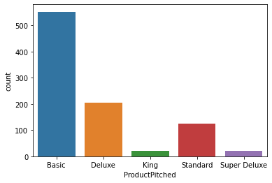

```python
sns.countplot(x="ProductPitched", data=df_cp);
```

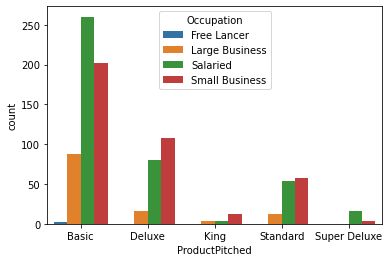

```python
sns.countplot(x="ProductPitched", data=df_cp,  hue="Occupation");
```

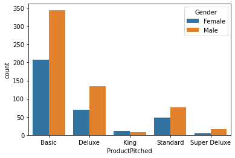

```python
sns.countplot(x="ProductPitched", data=df_cp,  hue="Gender");
```

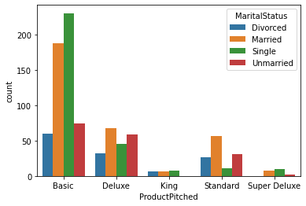

```python
sns.countplot(x="ProductPitched", data=df_cp, hue="MaritalStatus");
```

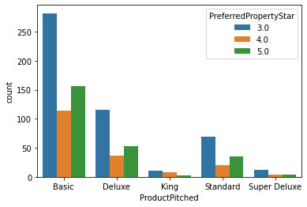

```python
sns.countplot(x="ProductPitched", data=df_cp,  hue="PreferredPropertyStar");
```

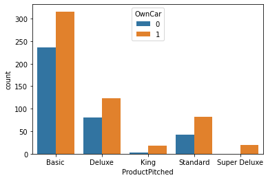

```python
sns.countplot(x="ProductPitched", data=df_cp,  hue="OwnCar");
```

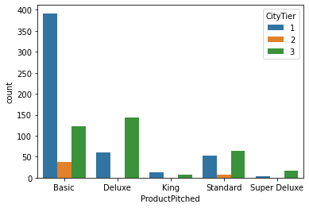

```python
sns.countplot(x="ProductPitched", data=df_cp,  hue="CityTier");
```

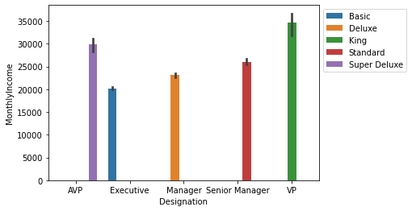

```python
sns.barplot(x='Designation',y='MonthlyIncome',data=df_cp,hue='ProductPitched');
plt.legend(bbox_to_anchor=(1, 1))
```

```
ProdTaken       0    1   All
Incomebin
All          3968  920  4888
Below30000   2682  576  3258
Below20000    754  284  1038
Below40000    528   60   588
Below10000      2    0     2
Below100000     2    0     2
------------------------------------------------------------------------------------------------------------------------
```

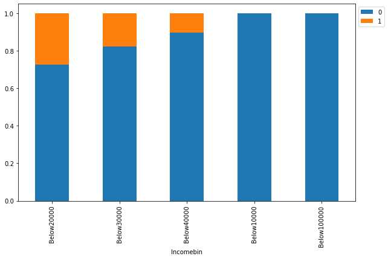

```python
stacked_barplot(data, "Incomebin", "ProdTaken")
```

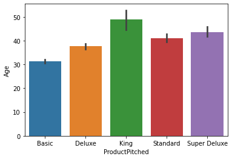

```python
sns.barplot(y='Age',x='ProductPitched',data=df_cp);
```

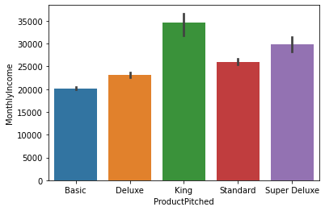

```python
sns.barplot(y='MonthlyIncome',x='ProductPitched',data=df_cp);
```

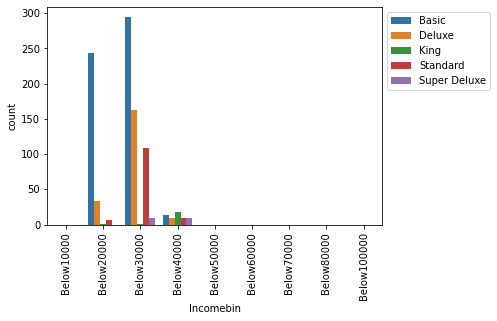

```python
sns.countplot(x='Incomebin',hue='ProductPitched',data=df_cp);
plt.xticks(rotation=90);
plt.legend(bbox_to_anchor=(1, 1));
```

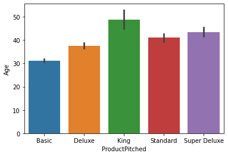

```python
sns.barplot(y='Age',x='ProductPitched',data=df_cp);
```

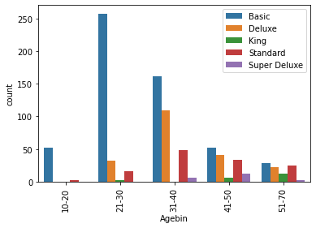

```python
sns.countplot(x='Agebin',hue='ProductPitched',data=df_cp);
plt.xticks(rotation=90);
plt.legend(bbox_to_anchor=(1, 1));
```

```
ProdTaken     0    1   All
Agebin
All        3968  920  4888
31-40      1772  325  2097
21-30       777  308  1085
41-50       929  144  1073
51-70       460   89   549
10-20        30   54    84
------------------------------------------------------------------------------------------------------------------------
```

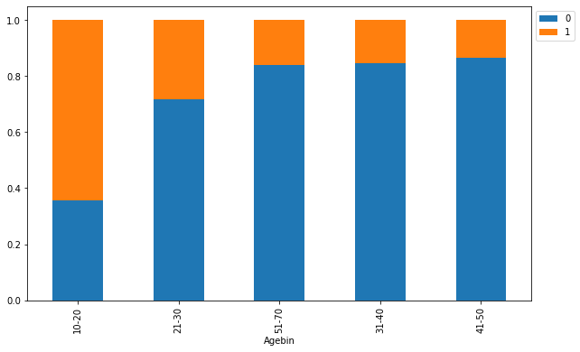

```python
stacked_barplot(data, "Agebin", "ProdTaken")
```